# act_report

## Data Analysis and Visualization

### Histogram of Overall Rating

The below histogram shows that the overall rating (ratio of numerator divided denominator) is left skewed. Since there are variations for the numerator and denominator values as discussed in the assess and clean sections, I chose to normalize the rating by taking the ratio of the numerator to denominator. As we can see, the ratings are rather on the higher end and more heavily skewed towards 1.0 and higher. In other words, most ratings are 10/10 or higher.

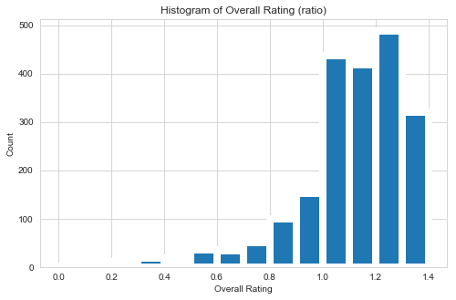

### Dog Stage Pie Chart

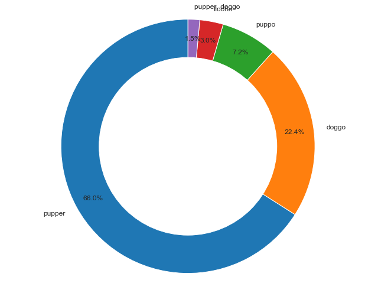

### Gender Pie Chart

Here's the dog's gender breakdown from the tweets. Male dogs account for about 75% and female at 25%. The gender is determined by matching the tweet's text to certain keywords. Not all tweets will result in a gender determination.

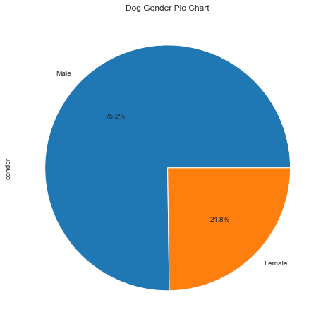

### Distribution of Favorites and Retweet Counts

Here's a look at the histogram of the favorite and retweet counts

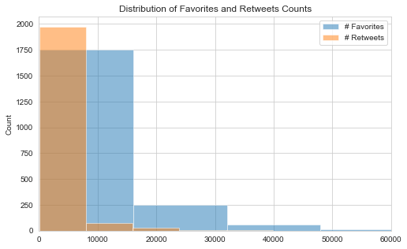

### Favorites vs Retweets Scatter Plot

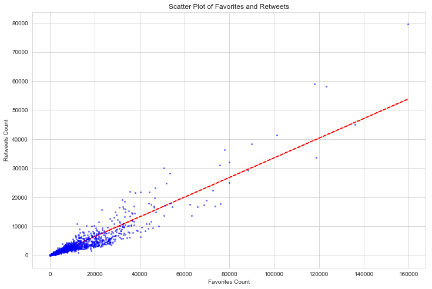

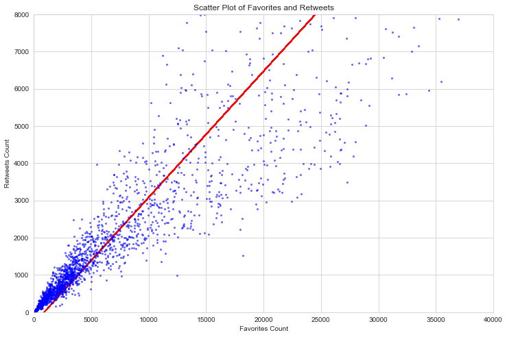

### Most Popular Day of Week to Post

Interestingly, Monday has the highest count of the day of the week when a tweet is originated based on its timestamp. Maybe people are most stressed on Mondays?

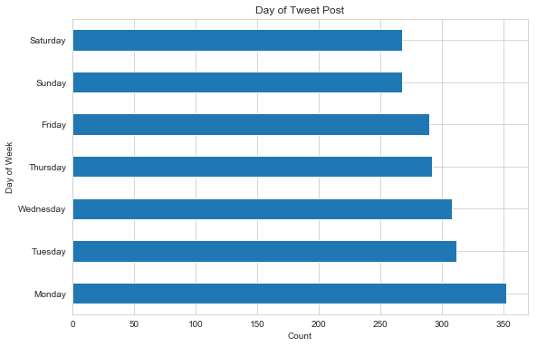

### Tweet Count by Year and Month

I used the timestamp and grouped them by year and month to determine the number tweets that originated by time period. As we can see, the number of tweets have certainly declined since the peak at January 2016 of over 350 tweets a month and is down to aboiut 50 tweets a month by July 2017.

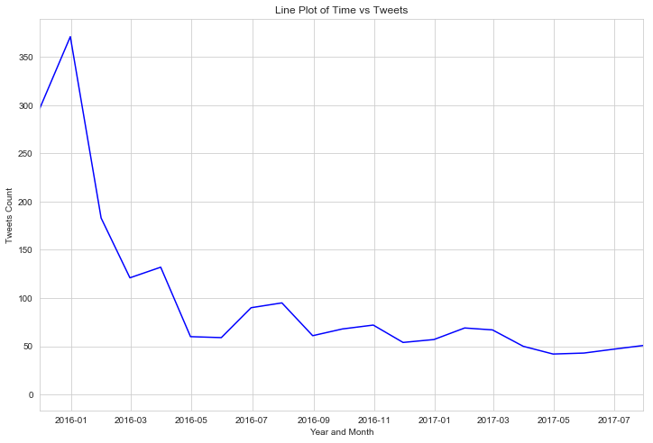

### Top 20 Dog Breeds based on tweeted picture

Not suprisingly, Golden Retreivers is most tweeted dog breed in WeRateDogs.

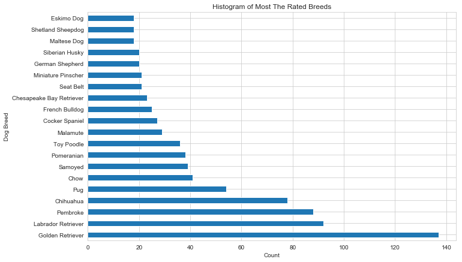

### Top 20 Dog Breeds based on favorite count

Now I calculate the top 20 dog breeds based on the amount of favorites that the tweet generates. Looks like the Golden Retriever comes out on top again, followed by the beloved Labrador Retriever. These are two of the most popular dogs in the US.

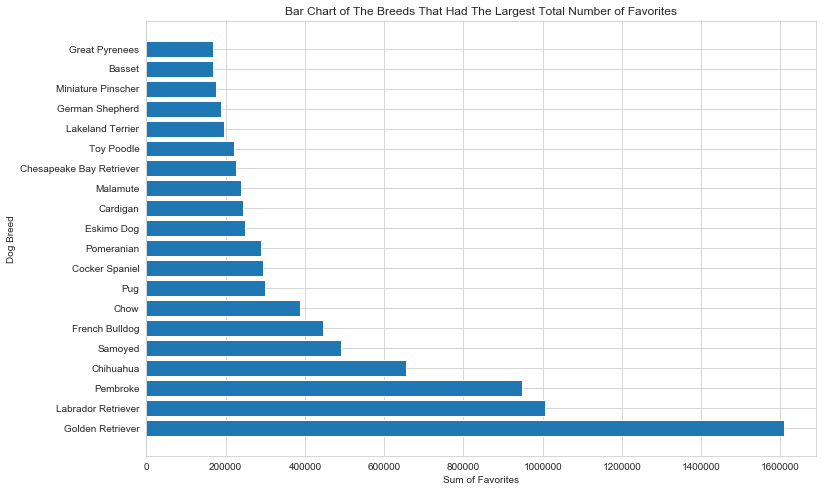